# Coursera - Reproduceable Research - Week 2 Assignment

Guido van Kleef

9 june 2019

### Download the data

```r
library(downloader)
```

```r
time <- Sys.time()
url <- "https://d396qusza40orc.cloudfront.net/repdata%2Fdata%2Factivity.zip"
if(!dir.exists("./data")){dir.create("./data")}
if(!file.exists("./data/data.zip")){download.file(url, destfile = "./data/data.zip")}
if(!file.exists("./data/activity.csv")){unzip("./data/data.zip", exdir = "./data")}
```

Data downloaded at 2019-06-09 21:48:42

### Load the data into R

```r
data <- read.csv("./data/activity.csv")
```

### Number of steps taken per day

1. Create a dataframe with the total_steps per day
2. Create a histogram based on the total steps per day

```r
library(dplyr)
```

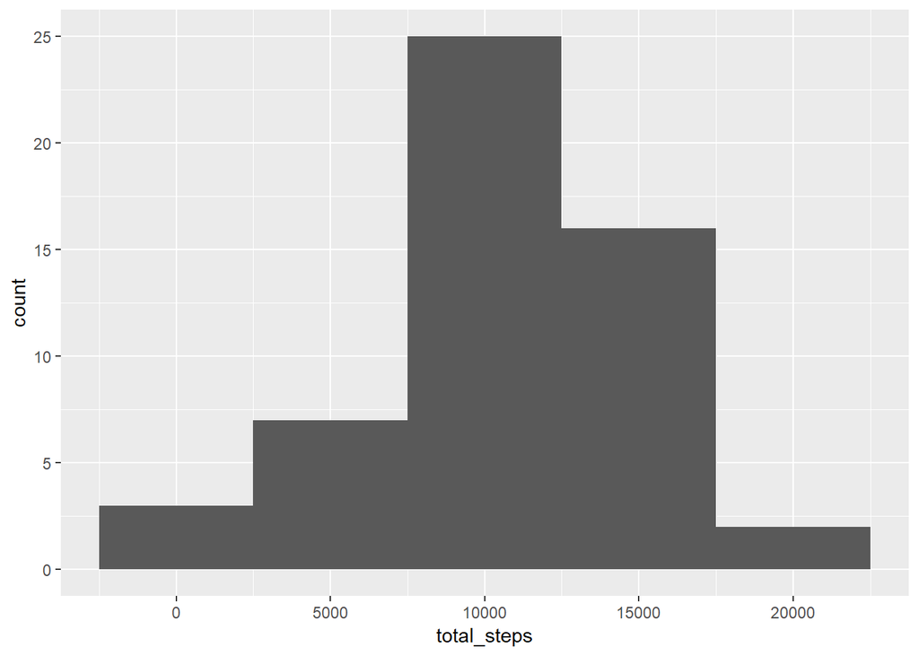

```r
library(ggplot2)
daily_steps <- data %>%
        group_by(data$date) %>%
        summarise(total_steps = sum(steps))

ggplot(daily_steps, aes(x = total_steps)) +
        geom_histogram(binwidth = 5000)
```

Mean and median of total steps per day

```r
print(c(median = median(daily_steps$total_steps, na.rm = T), mean = mean(daily_steps$total_steps, na.rm = T)))
```

```
##   median     mean
## 10765.00 10766.19
```

### Average daily activity pattern

1. Create a dataframe with the average steps per 5 minute interval
2. Create a line plot that shows the average steps per 5 minute interval

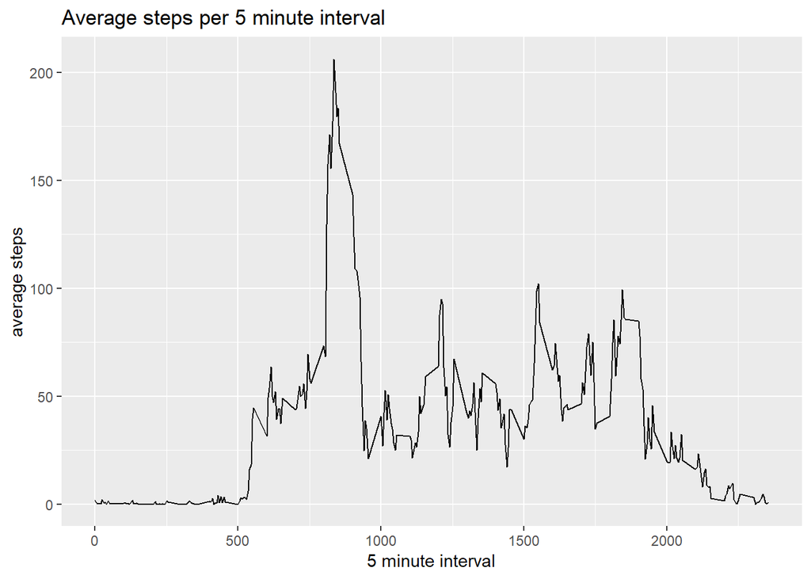

```r
avg_steps <- data %>%
        group_by(interval) %>%
        summarise(avg_steps = mean(steps, na.rm = TRUE))

ggplot(avg_steps, aes(x = interval, y = avg_steps)) +
        geom_line() +
        labs(title = "Average steps per 5 minute interval",
             x = "5 minute interval",
             y = "average steps")
```

The 5 minute interval with maximum number of average daily steps

```r
max <- max(avg_steps$avg_steps)
print(avg_steps$interval[avg_steps$avg_steps == max])
```

```
## [1] 835
```

### Imput missing values

1. number of missing values

```r
sum(is.na(data))
```

```
## [1] 2304
```

2. replacing missing values by the avg for the 5 minute interval

```r
data_correction <- data %>%
        group_by(interval) %>%
        mutate(steps = replace(steps, is.na(steps), mean(steps, na.rm = T)))
```

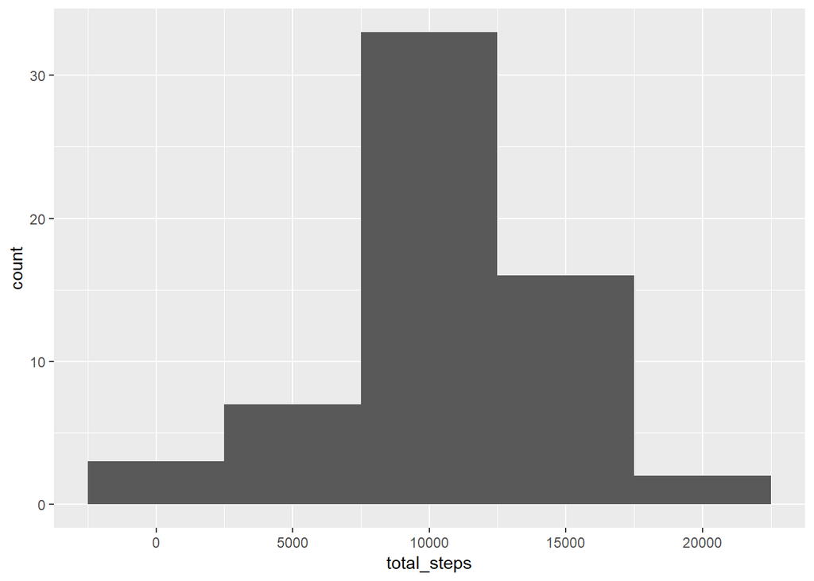

```r
daily_steps_corrected <- data_correction %>%
        group_by(date) %>%
        summarise(total_steps = sum(steps))

ggplot(daily_steps_corrected, aes(x = total_steps)) +
        geom_histogram(binwidth = 5000)
```

4. The mean and median of the corrected data The median becomes equal to the mean, because we replaced the missing values by the mean of each group

```r
print(c(median = median(daily_steps_corrected$total_steps, na.rm = T), mean = mean(daily_steps_corrected$total_steps, na.rm = T)))
```

```
##   median     mean
## 10766.19 10766.19
```

### Differences in activity patterns between weekdays and weekends

[figure not shown]

```r
avg_weekdays <- data_correction %>%
        mutate(weekdays = weekdays(as.Date(date))) %>%
        mutate(weekdays = as.factor(case_when(grepl('Saturday|Sunday', weekdays) ~ "Weekend"
                                    , !grepl('Saturday|Sunday', weekdays) ~ "Weekday",
                                    TRUE ~ weekdays))) %>%
        group_by(weekdays,interval) %>%
        summarise(avg_steps = mean(steps))

ggplot(avg_weekdays, aes(x = interval, y = avg_steps)) +
        geom_line() +
        facet_wrap(.~ weekdays) +
        labs(title = "avg steps per 5 minute interval by weekend & weekdays",
             x = "5 minute interval",
             y = "Average steps")
```